# Exam 2

Jake Hiltscher

## Exam Instructions

Use this .rmd file to perform your analysis. You will answer questions about this data set through a Canvas Quiz. You will then submit your completed .rmd and .html file at the end of the Canvas quiz. Your code should be organized, properly formatted, and you should only print out relevant items (e.g. do not print out the entire data set for me to see, and do not use the `View()` function).

## Data and Description

Researchers collected data on 414 homes in China. The goal is to use rather unique explanatory variables to predict house price (measured in cost (US Dollars) per unit area). The following are predictor variables:

| Variable | Description |
| --- | --- |
| age | Age of the house (number of years since being built) in years |
| stores | Number of convenience stores within a 500 meter circle around the house |
| metro | Distance from the house to the nearest metro station (in meters) |
| trails | Distance from the house to the nearest walking trail (in meters) |

Download the RealEstate.txt file from Canvas (Files -> DATA SETS), and put it in the same folder as this R Markdown file.

### Complete your exploratory data analysis (EDA) in this section. You may use multiple code chunks, if you wish, to organize your code.

```r
real_estate <- read_table("RealEstate.txt")
real_estate <- as.data.frame(real_estate)
summary(real_estate)
```

```
##       age             price            stores           metro
##  Min.   : 0.000   Min.   :  7.60   Min.   : 0.000   Min.   :  23.38
##  1st Qu.: 9.025   1st Qu.: 27.70   1st Qu.: 1.000   1st Qu.: 289.32
##  Median :16.100   Median : 38.45   Median : 4.000   Median : 492.23
##  Mean   :17.713   Mean   : 37.98   Mean   : 4.094   Mean   :1083.89
##  3rd Qu.:28.150   3rd Qu.: 46.60   3rd Qu.: 6.000   3rd Qu.:1454.28
##  Max.   :43.800   Max.   :117.50   Max.   :10.000   Max.   :6488.02
##      trails
##  Min.   :  15
##  1st Qu.:5877
##  Median :6550
##  Mean   :6306
##  3rd Qu.:7069
##  Max.   :9231
```

### Fit an inital model, and check the “(A) no influential points” assumption in this section. You may use multiple code chunks, if you wish, to organize your code.

```r
real_estate_lm <- lm(price ~ ., data = real_estate)
summary(real_estate_lm)
```

```
##
## Call:
## lm(formula = price ~ ., data = real_estate)
##
## Residuals:
##     Min      1Q  Median      3Q     Max
## -36.831  -5.360  -1.508   4.207  77.139
##
## Coefficients:
##               Estimate Std. Error t value Pr(>|t|)
## (Intercept) 48.3339770  4.8388928   9.989  < 2e-16 ***
## age         -0.2505982  0.0401366  -6.244 1.07e-09 ***
## stores       1.2861069  0.1944583   6.614 1.17e-10 ***
## metro       -0.0060168  0.0007140  -8.427 6.10e-16 ***
## trails      -0.0007388  0.0006395  -1.155    0.249
## ---
## Signif. codes:  0 '***' 0.001 '**' 0.01 '*' 0.05 '.' 0.1 ' ' 1
##
## Residual standard error: 9.248 on 409 degrees of freedom
## Multiple R-squared:  0.5426, Adjusted R-squared:  0.5381
## F-statistic: 121.3 on 4 and 409 DF,  p-value: < 2.2e-16
```

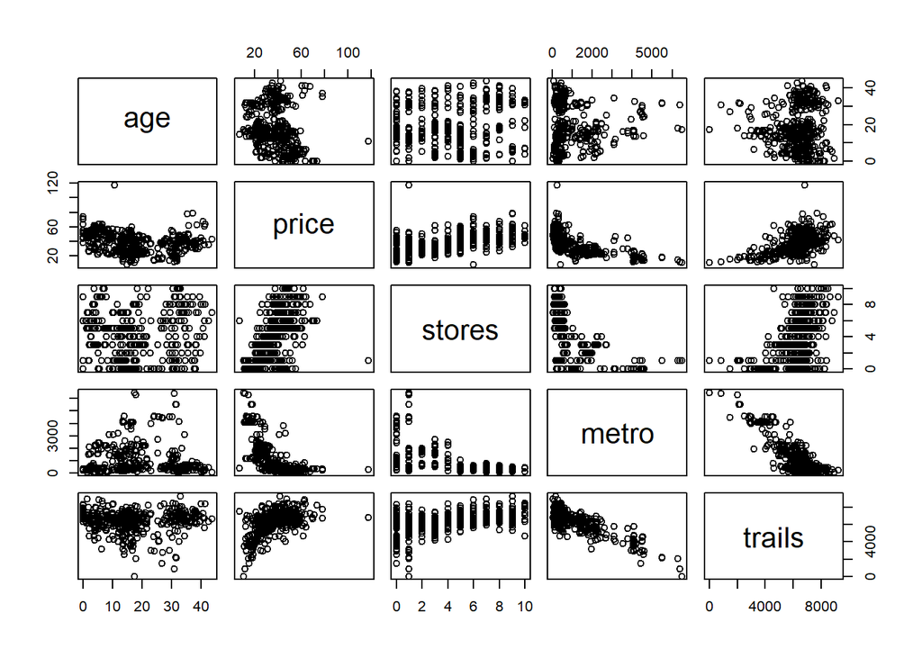

```r
pairs(real_estate)
```

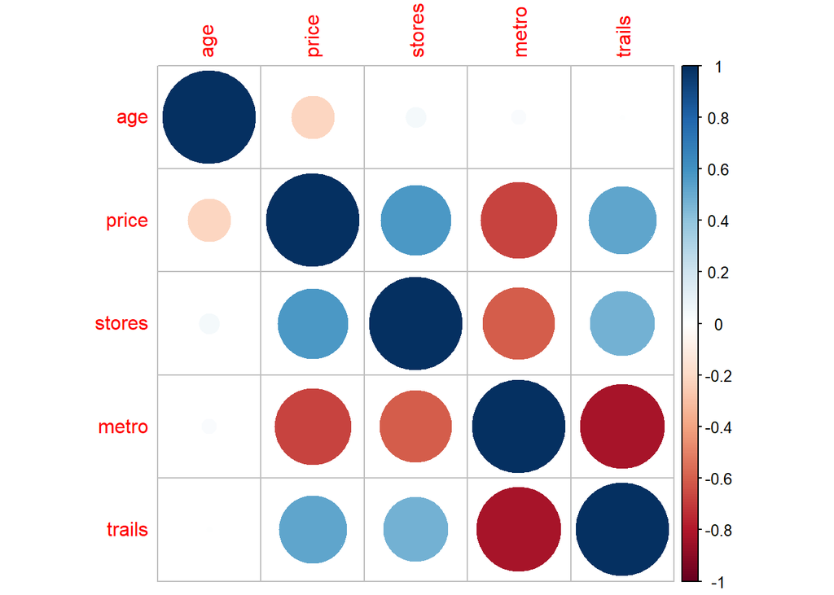

```r
corrplot(cor(real_estate))
```

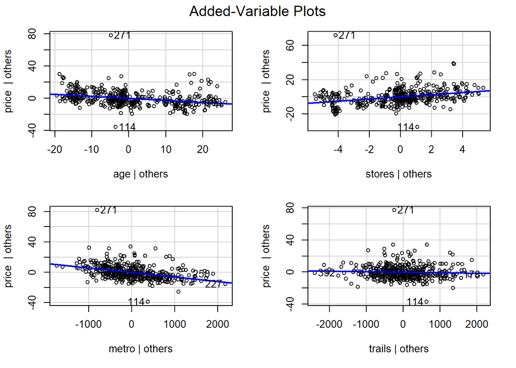

```r
avPlots(real_estate_lm)
```

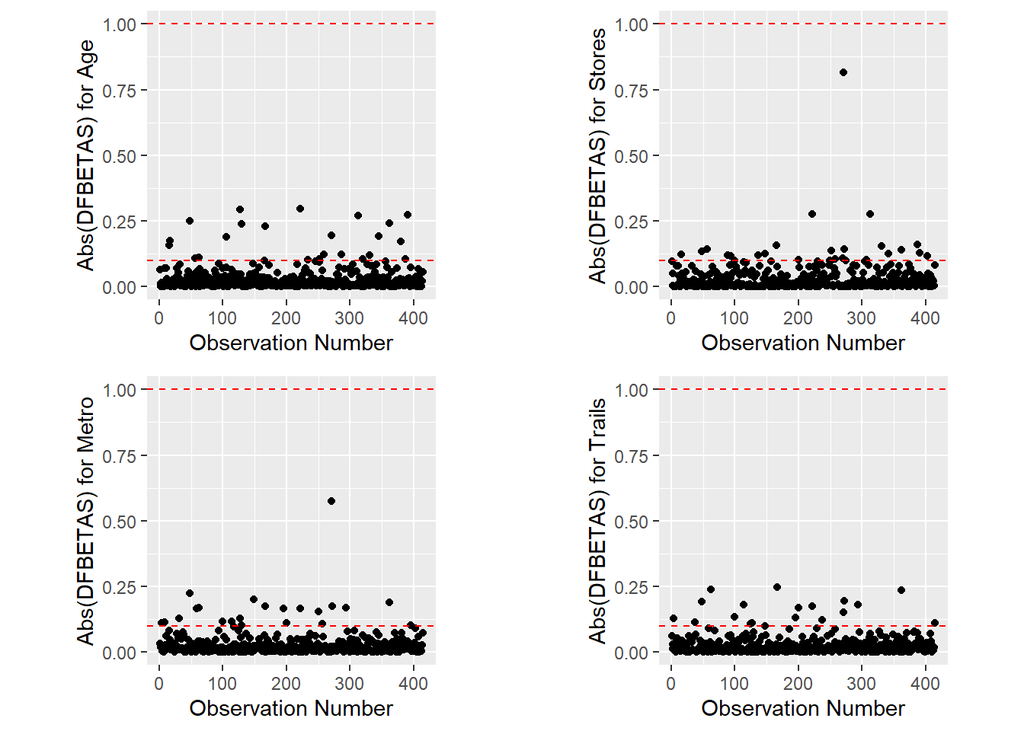

```r
# age -------------------------------------------------------------------
# calculate the DFBETAS for age
real_estate$dfbetas_age <- as.vector(dfbetas(real_estate_lm)[, "age"])
# plot the DFBETAS against the observation number
dfbetas_plot_age <- ggplot(data = real_estate) +
  geom_point(mapping = aes(x = as.numeric(rownames(real_estate)),
                           y = abs(dfbetas_age))) +
  ylab("Abs(DFBETAS) for Age") +
  xlab("Observation Number") +
  # for n > 30
  geom_hline(mapping = aes(yintercept = 2 / sqrt(length(dfbetas_age))),
             color = "red",
             linetype = "dashed") +
  # for n <= 30
  geom_hline(mapping = aes(yintercept = 1),
             color = "red",
             linetype = "dashed") +
  theme(aspect.ratio = 1)
# stores -------------------------------------------------------------------
# calculate the DFBETAS for stores
real_estate$dfbetas_stores <- as.vector(dfbetas(real_estate_lm)[, "stores"])
# plot the DFBETAS against the observation number
dfbetas_plot_stores <- ggplot(data = real_estate) +
  geom_point(mapping = aes(x = as.numeric(rownames(real_estate)),
                           y = abs(dfbetas_stores))) +
  ylab("Abs(DFBETAS) for Stores") +
  xlab("Observation Number") +
  # for n > 30
  geom_hline(mapping = aes(yintercept = 2 / sqrt(length(dfbetas_stores))),
             color = "red",
             linetype = "dashed") +
  # for n <= 30
  geom_hline(mapping = aes(yintercept = 1),
             color = "red",
             linetype = "dashed") +
  theme(aspect.ratio = 1)
# metro -------------------------------------------------------------------
# calculate the DFBETAS for metro
real_estate$dfbetas_metro <- as.vector(dfbetas(real_estate_lm)[, "metro"])
# plot the DFBETAS against the observation number
dfbetas_plot_metro <- ggplot(data = real_estate) +
  geom_point(mapping = aes(x = as.numeric(rownames(real_estate)),
                           y = abs(dfbetas_metro))) +
  ylab("Abs(DFBETAS) for Metro") +
  xlab("Observation Number") +
  # for n > 30
  geom_hline(mapping = aes(yintercept = 2 / sqrt(length(dfbetas_metro))),
             color = "red",
             linetype = "dashed") +
  # for n <= 30
  geom_hline(mapping = aes(yintercept = 1),
             color = "red",
             linetype = "dashed") +
  theme(aspect.ratio = 1)
# trails -------------------------------------------------------------------
# calculate the DFBETAS for trails
real_estate$dfbetas_trails <- as.vector(dfbetas(real_estate_lm)[, "trails"])
# plot the DFBETAS against the observation number
dfbetas_plot_trails <- ggplot(data = real_estate) +
  geom_point(mapping = aes(x = as.numeric(rownames(real_estate)),
                           y = abs(dfbetas_trails))) +
  ylab("Abs(DFBETAS) for Trails") +
  xlab("Observation Number") +
  # for n > 30
  geom_hline(mapping = aes(yintercept = 2 / sqrt(length(dfbetas_trails))),
             color = "red",
             linetype = "dashed") +
  # for n <= 30
  geom_hline(mapping = aes(yintercept = 1),
             color = "red",
             linetype = "dashed") +
  theme(aspect.ratio = 1)
grid.arrange(dfbetas_plot_age,
             dfbetas_plot_stores,
             dfbetas_plot_metro,
             dfbetas_plot_trails,
             nrow = 2)
```

### Fit a model on a new data set where the one influential point is removed, and check the “no multicollinearity” assumption, in this section. You may use multiple code chunks, if you wish, to organize your code.

```r
# Removing influential point (Observation 271)
real_estate <- read_table("RealEstate.txt")
real_estate <- as.data.frame(real_estate)
new_real_estate <- real_estate[-271, ]

new_real_estate_lm <- lm(price ~ ., data = new_real_estate)
summary(new_real_estate_lm)
```

```
##
## Call:
## lm(formula = price ~ ., data = new_real_estate)
##
## Residuals:
##     Min      1Q  Median      3Q     Max
## -36.745  -5.279  -1.576   4.353  34.088
##
## Coefficients:
##               Estimate Std. Error t value Pr(>|t|)
## (Intercept) 46.4637327  4.4125950  10.530  < 2e-16 ***
## age         -0.2434771  0.0365700  -6.658 8.99e-11 ***
## stores       1.4304034  0.1778301   8.044 9.57e-15 ***
## metro       -0.0056424  0.0006517  -8.659  < 2e-16 ***
## trails      -0.0006502  0.0005826  -1.116    0.265
## ---
## Signif. codes:  0 '***' 0.001 '**' 0.01 '*' 0.05 '.' 0.1 ' ' 1
##
## Residual standard error: 8.424 on 408 degrees of freedom
## Multiple R-squared:  0.5871, Adjusted R-squared:  0.5831
## F-statistic:   145 on 4 and 408 DF,  p-value: < 2.2e-16
```

```r
vif(new_real_estate_lm)
```

```
##      age   stores    metro   trails
## 1.009291 1.592574 3.932695 3.228700
```

### Fit another model (on the new data set where the one influential point is removed) with the age variable square rooted (do not use the original age variable) in this section.

```r
sqrt_real_estate_lm <- lm(price ~ sqrt(age) +.-age,data = new_real_estate)
summary(sqrt_real_estate_lm)
```

```
##
## Call:
## lm(formula = price ~ sqrt(age) + . - age, data = new_real_estate)
##
## Residuals:
##     Min      1Q  Median      3Q     Max
## -36.031  -5.248  -1.264   4.052  34.104
##
## Coefficients:
##               Estimate Std. Error t value Pr(>|t|)
## (Intercept) 50.2432792  4.3654110  11.509  < 2e-16 ***
## sqrt(age)   -2.1144686  0.2613058  -8.092 6.81e-15 ***
## stores       1.4477069  0.1738040   8.330 1.25e-15 ***
## metro       -0.0054377  0.0006385  -8.516 3.21e-16 ***
## trails      -0.0006697  0.0005692  -1.177     0.24
## ---
## Signif. codes:  0 '***' 0.001 '**' 0.01 '*' 0.05 '.' 0.1 ' ' 1
##
## Residual standard error: 8.234 on 408 degrees of freedom
## Multiple R-squared:  0.6056, Adjusted R-squared:  0.6017
## F-statistic: 156.6 on 4 and 408 DF,  p-value: < 2.2e-16
```

```r
sqrt_real_estate <- new_real_estate
sqrt_real_estate$age_sqrt <- sqrt(sqrt_real_estate$age)
```

### Perform variable selection in this section. You may use multiple code chunks, if you wish, to organize your code.

```r
real_estate <- sqrt_real_estate[ , c("age_sqrt", "stores", "metro", "trails", "price")]
# Backwards selection
best_subsets_bic <- bestglm(real_estate,
                            IC = "BIC",
                            method = "exhaustive")

# view variables included in the top 10 models
best_subsets_bic$BestModels
```

```
##   age_sqrt stores metro trails Criterion
## 1     TRUE   TRUE  TRUE  FALSE  1755.835
## 2     TRUE   TRUE  TRUE   TRUE  1760.460
## 3    FALSE   TRUE  TRUE  FALSE  1811.772
## 4     TRUE  FALSE  TRUE  FALSE  1815.486
## 5    FALSE   TRUE  TRUE   TRUE  1815.908
```

```r
# view a summary of the "best" model
summary(best_subsets_bic$BestModel)
```

```
##
## Call:
## lm(formula = y ~ ., data = data.frame(Xy[, c(bestset[-1], FALSE),
##     drop = FALSE], y = y))
##
## Residuals:
##     Min      1Q  Median      3Q     Max
## -36.453  -5.206  -1.317   4.308  33.679
##
## Coefficients:
##               Estimate Std. Error t value Pr(>|t|)
## (Intercept) 45.3932499  1.4373253  31.582  < 2e-16 ***
## age_sqrt    -2.1256800  0.2612546  -8.136 4.94e-15 ***
## stores       1.4580841  0.1736616   8.396 7.64e-16 ***
## metro       -0.0048585  0.0004068 -11.942  < 2e-16 ***
## ---
## Signif. codes:  0 '***' 0.001 '**' 0.01 '*' 0.05 '.' 0.1 ' ' 1
##
## Residual standard error: 8.238 on 409 degrees of freedom
## Multiple R-squared:  0.6042, Adjusted R-squared:  0.6013
## F-statistic: 208.1 on 3 and 409 DF,  p-value: < 2.2e-16
```

```r
# PMSE selection
best_subsets_pmse <- bestglm(real_estate,
                             IC ="CV")

# view variables included in the top 10 models
best_subsets_pmse
```

```
## CVd(d = 331, REP = 1000)
## BICq equivalent for q in (1.62334590214641e-11, 0.909889773196609)
## Best Model:
##                 Estimate   Std. Error    t value      Pr(>|t|)
## (Intercept) 45.393249945 1.4373253400  31.581750 9.521737e-112
## age_sqrt    -2.125680023 0.2612546136  -8.136431  4.936541e-15
## stores       1.458084130 0.1736615848   8.396124  7.643437e-16
## metro       -0.004858459 0.0004068317 -11.942184  2.085863e-28
```

```r
# view a summary of the "best" model
summary(best_subsets_pmse)
```

```
## Fitting algorithm:  CVd(d = 331, REP = 1000)-leaps
## Best Model:
##             df deviance
## Null Model 409 27753.33
## Full Model 412 70122.67
##
##  likelihood-ratio test - GLM
##
## data:  H0: Null Model vs. H1: Best Fit CVd(d = 331, REP = 1000)-leaps
## X = 42369, df = 3, p-value < 2.2e-16
```

### Fit a model with any variables removed that you deem unnecesary for the model in this section.

```r
screen_real_estate <- sqrt_real_estate[ , c("age_sqrt", "stores", "metro", "price")]
summary(screen_real_estate)
```

```
##     age_sqrt         stores           metro             price
##  Min.   :0.000   Min.   : 0.000   Min.   :  23.38   Min.   : 7.60
##  1st Qu.:3.000   1st Qu.: 1.000   1st Qu.: 289.32   1st Qu.:27.70
##  Median :4.012   Median : 4.000   Median : 492.23   Median :38.40
##  Mean   :3.910   Mean   : 4.102   Mean   :1085.90   Mean   :37.79
##  3rd Qu.:5.310   3rd Qu.: 6.000   3rd Qu.:1455.80   3rd Qu.:46.60
##  Max.   :6.618   Max.   :10.000   Max.   :6488.02   Max.   :78.30
```

```r
screen_real_estate_lm <- lm(price ~., data = screen_real_estate)
summary(screen_real_estate_lm)
```

```
##
## Call:
## lm(formula = price ~ ., data = screen_real_estate)
##
## Residuals:
##     Min      1Q  Median      3Q     Max
## -36.453  -5.206  -1.317   4.308  33.679
##
## Coefficients:
##               Estimate Std. Error t value Pr(>|t|)
## (Intercept) 45.3932499  1.4373253  31.582  < 2e-16 ***
## age_sqrt    -2.1256800  0.2612546  -8.136 4.94e-15 ***
## stores       1.4580841  0.1736616   8.396 7.64e-16 ***
## metro       -0.0048585  0.0004068 -11.942  < 2e-16 ***
## ---
## Signif. codes:  0 '***' 0.001 '**' 0.01 '*' 0.05 '.' 0.1 ' ' 1
##
## Residual standard error: 8.238 on 409 degrees of freedom
## Multiple R-squared:  0.6042, Adjusted R-squared:  0.6013
## F-statistic: 208.1 on 3 and 409 DF,  p-value: < 2.2e-16
```

### Determine if any interaction(s) are needed for this model in this section. You may use multiple code chunks, if you wish, to organize your code.

```r
screen_real_estate_lm <- lm(price ~.+age_sqrt*stores+age_sqrt*metro+stores*metro, data = screen_real_estate)
summary(screen_real_estate_lm)
```

```
##
## Call:
## lm(formula = price ~ . + age_sqrt * stores + age_sqrt * metro +
##     stores * metro, data = screen_real_estate)
##
## Residuals:
##     Min      1Q  Median      3Q     Max
## -36.374  -4.535  -0.789   3.918  33.183
##
## Coefficients:
##                   Estimate Std. Error t value Pr(>|t|)
## (Intercept)     49.7291305  2.5265561  19.683  < 2e-16 ***
## age_sqrt        -3.1128259  0.5840790  -5.329 1.64e-07 ***
## stores           1.4786154  0.3967870   3.726 0.000222 ***
## metro           -0.0083722  0.0014812  -5.652 2.99e-08 ***
## age_sqrt:stores  0.0835203  0.0895952   0.932 0.351789
## age_sqrt:metro   0.0010328  0.0003256   3.172 0.001631 **
## stores:metro    -0.0012075  0.0002165  -5.578 4.45e-08 ***
## ---
## Signif. codes:  0 '***' 0.001 '**' 0.01 '*' 0.05 '.' 0.1 ' ' 1
##
## Residual standard error: 7.834 on 406 degrees of freedom
## Multiple R-squared:  0.6446, Adjusted R-squared:  0.6394
## F-statistic: 122.8 on 6 and 406 DF,  p-value: < 2.2e-16
```

```r
anova(screen_real_estate_lm)
```

```
## Analysis of Variance Table
##
## Response: price
##                  Df  Sum Sq Mean Sq  F value    Pr(>F)
## age_sqrt          1  6247.8  6247.8 101.7956 < 2.2e-16 ***
## stores            1 26444.1 26444.1 430.8519 < 2.2e-16 ***
## metro             1  9677.4  9677.4 157.6736 < 2.2e-16 ***
## age_sqrt:stores   1    32.0    32.0   0.5215 0.4706381
## age_sqrt:metro    1   892.9   892.9  14.5475 0.0001579 ***
## stores:metro      1  1909.7  1909.7  31.1145 4.449e-08 ***
## Residuals       406 24918.8    61.4
## ---
## Signif. codes:  0 '***' 0.001 '**' 0.01 '*' 0.05 '.' 0.1 ' ' 1
```

```r
screen_real_estate_lm <- lm(price ~.+age_sqrt*metro+stores*metro, data = screen_real_estate)
```

Two interactions are needed - Age:metro and stores:metro.

### Complete statistical inference based on the best linear model you chose in this section. You may use multiple code chunks, if you wish, to organize your code.

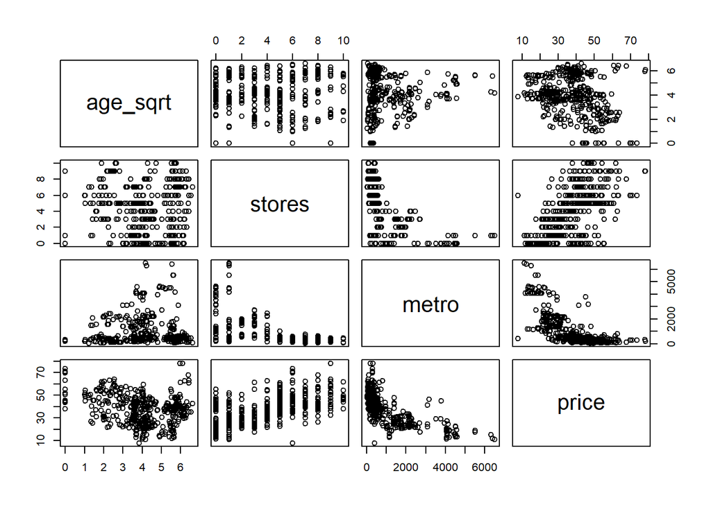

```r
# <your code here>
pairs(screen_real_estate)
```

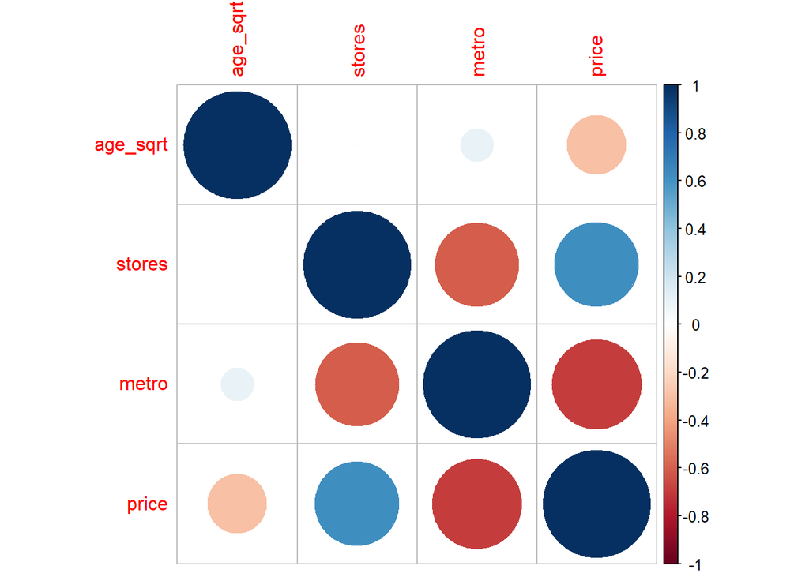

```r
corrplot(cor(screen_real_estate))
```

```r
predict(screen_real_estate_lm,
        newdata = data.frame(age_sqrt = 20, stores = 3, metro = 500, trails = 6000),
        level = 0.95,
        interval = "confidence")
```

```
##        fit       lwr      upr
## 1 3.756026 -4.295581 11.80763
```